# Project Python Foundations: FoodHub Data Analysis

### Observations: The most common cost of the order was 11-12 dollars. The most common rating for orders was 5. The most common delivery time was at about 28 minutes.50% of the orders cost between 13-23 dollars. 50% of the ratings fell between 4 and 5. 50% of the food preparation time was between 23 and 31 minutes. 50% of the delivery times were between 20 and 28 minutes. The Weekend had more than twice the amount of orders as Weekdays. American, Japanese, Italian and Chinese were the most popular cuisine types ordered.

### **Question 7**: Which are the top 5 restaurants in terms of the number of orders received? [1 mark]

```python
# Getting the top 5 rows with the highest number of orders received
top5= df_new['restaurant_name'].value_counts().head()
top5
```

| restaurant_name | count |
| --- | --- |
| Shake Shack | 219 |
| The Meatball Shop | 132 |
| Blue Ribbon Sushi | 119 |
| Blue Ribbon Fried Chicken | 96 |
| Parm | 68 |

**dtype:** int64

#### Observations: In terms of number of orders received, the top restaurants are: Shake Shack, The Meatball Shop, Blue Ribbon Sushi, Blue Ribbon Fried Chicken and Parm.

### **Question 8**: Which is the most popular cuisine on weekends? [1 mark]

```python
# Retrieving row with the highest value count under cuisine type for weekends
weekend_df= df_new.loc[df_new['day_of_the_week'] == 'Weekend']
cuisine_wknd = weekend_df['cuisine_type'].value_counts()
print('The most popular cuisine on the weekends is', cuisine_wknd.index[0])
```

```
The most popular cuisine on the weekends is American
```

#### Observations: American is the most popular cuisine on the weekends.

### **Question 9**: What percentage of the orders cost more than 20 dollars? [2 marks]

```python
# Filtering for orders where 'cost_of_the_order' is greater than 20
orders_over_20 = df_new.loc[df['cost_of_the_order'] > 20]
# Getting percentage by dividing the number of orders_over_20 by number of orders total and multiplying by 100
percentage = (orders_over_20.shape[0]/df_new.shape[0])*100
print(percentage)
```

```
29.24130663856691
```

### **Question 10**: What is the mean order delivery time? [1 mark]

```python
# Finding the mean of delivery time
df_new['delivery_time'].mean()
```

```
np.float64(24.161749209694417)
```

### **Question 11:** The company has decided to give 20% discount vouchers to the top 3 most frequent customers. Find the IDs of these customers and the number of orders they placed. [1 mark]

```python
# Finding the top 3 most frequent values under 'customer_id'
top_customers = df_new['customer_id'].value_counts().head(3)
top_customers
```

| customer_id | count |
| --- | --- |
| 52832 | 13 |
| 47440 | 10 |
| 83287 | 9 |

**dtype:** int64

#### Observations: Customer 52832 is the most frequent with 13 orders placed, followed by Customer 47440 with 10 orders and Customer 83287 with 9 orders.

### **Question 12**: Perform a multivariate analysis to explore relationships between the important variables in the dataset. (It is a good idea to explore relations between numerical variables as well as relations between numerical and categorical variables) [10 marks]

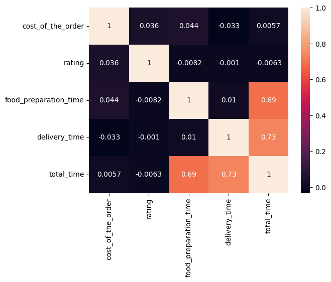

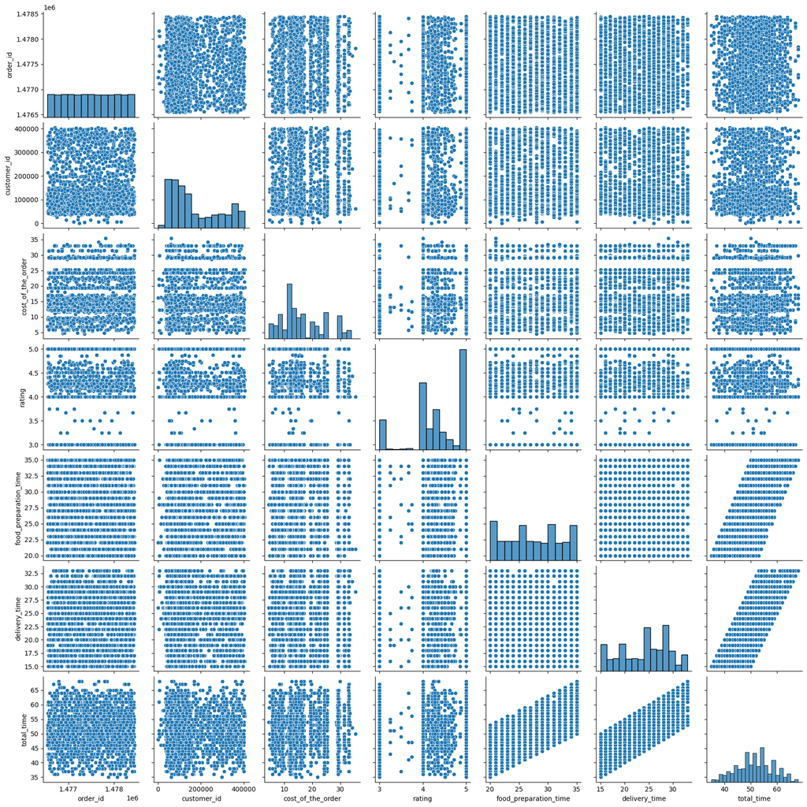

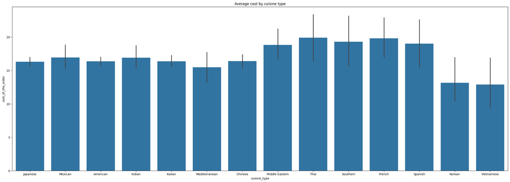

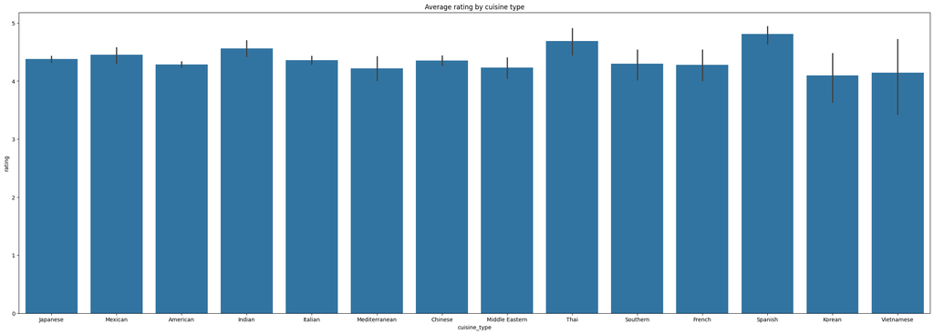

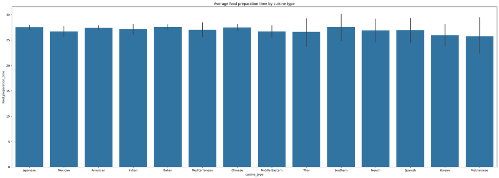

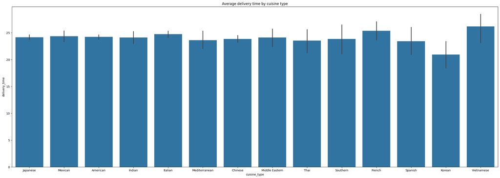

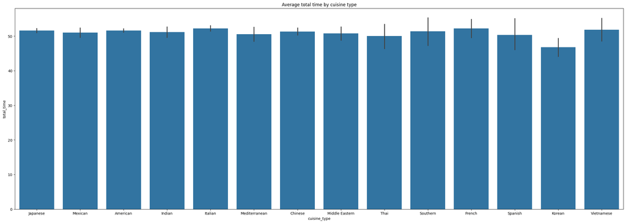

```python
# Create a total time column
df_new['total_time'] = df_new['food_preparation_time'] + df_new['delivery_time']
# Dropping rows with missing values in columns
df_new.dropna(inplace=True)
# Dropping ID columns and keeping only numeric variables
numeric_cols = df_new.select_dtypes(include='number').drop(columns=['order_id', 'customer_id'])
corr_matrix = numeric_cols.corr()
# Plot a heatmap of numeric only columns
sns.heatmap(corr_matrix, annot=True)
plt.show()

# Using pairplot to visualize pairwise relationships
sns.pairplot(df_new)
plt.show()

# Finding average cost by cuisine type
plt.figure(figsize=(30,10))
sns.barplot(data = df_new, x = 'cuisine_type', y = 'cost_of_the_order')
plt.title('Average cost by cuisine type')
plt.show()

#Finding average rating by cuisine type
plt.figure(figsize=(30,10))
sns.barplot(data = df_new, x = 'cuisine_type', y = 'rating')
plt.title('Average rating by cuisine type')
plt.show()

#Finding average food preparation time by cuisine type
plt.figure(figsize=(30,10))
sns.barplot(data = df_new, x = 'cuisine_type', y = 'food_preparation_time')
plt.title('Average food preparation time by cuisine type')
plt.show()

#Finding average delivery time by cuisine type
plt.figure(figsize=(30,10))
sns.barplot(data = df_new, x = 'cuisine_type', y = 'delivery_time')
plt.title('Average delivery time by cuisine type')

#Finding average total time by cuisine type
plt.figure(figsize=(30,10))
sns.barplot(data = df_new, x = 'cuisine_type', y = 'total_time')
plt.title('Average total time by cuisine type')
plt.show()
```

### **Question 13:** The company wants to provide a promotional offer in the advertisement of the restaurants. The condition to get the offer is that the restaurants must have a rating count of more than 50 and the average rating should be greater than 4. Find the restaurants fulfilling the criteria to get the promotional offer. [3 marks]

```python
# Grouping the ratings by restaurant name and retrieving
# - count of ratings
# - average rating
rating_df = df.groupby('restaurant_name')['rating'].agg(['count','mean'])

# Filtering results
top_restaurants = rating_df.loc[(rating_df['count'] > 50) & (rating_df['mean'] > 4)]
top_restaurants
```

| restaurant_name | count | mean |
| --- | --- | --- |
| Blue Ribbon Fried Chicken | 64 | 4.328125 |
| Blue Ribbon Sushi | 73 | 4.219178 |
| Shake Shack | 133 | 4.278195 |
| The Meatball Shop | 84 | 4.511905 |

#### Observations: The restaurants that meet the criteria to get the promotional offer are: Blue Ribbon Fried Chicken, Blue Ribbon Sushi, Shake Shack, and The Meatball Shop.

### **Question 14:** The company charges the restaurant 25% on the orders having cost greater than 20 dollars and 15% on the orders having cost greater than 5 dollars. Find the net revenue generated by the company across all orders. [3 marks]

```python
# Defining function to calculate revenue per order
def calculate_revenue(cost):
    if cost > 20:
        return cost * 0.25
    elif cost > 5:
        return cost * 0.15
    else:
        return 0
#Apply function to the column
df['revenue'] = df['cost_of_the_order'].apply(calculate_revenue)
# Calculate total revenue
net_revenue = df['revenue'].sum()

print('The net revenue generated by the company is $',net_revenue)
```

```
The net revenue generated by the company is $ 6166.303
```

#### Observations: Assuming the company doesn't charge on orders under 5 dollars, and using the original dataframe before missing value treatment, the net revenue generated by the company would be 6166.30 dollars.

### **Question 15:** The company wants to analyze the total time required to deliver the food. What percentage of orders take more than 60 minutes to get delivered from the time the order is placed? (The food has to be prepared and then delivered.) [2 marks]

```python
# Finding total time per order
df_new['total_time'] = df_new['food_preparation_time'] + df_new['delivery_time']
# Count orders taking more than 60 min
orders_over_60= df_new.loc[df_new['total_time'] > 60]
# Calculate percentage of those orders
perc_over_60 = (orders_over_60.shape[0]/df_new.shape[0])*100
print(perc_over_60)
```

```
10.537407797681771
```

#### Observations: About 10.53% of orders took more than 60 minutes to get delivered from the time the order was placed.

### **Question 16:** The company wants to analyze the delivery time of the orders on weekdays and weekends. How does the mean delivery time vary during weekdays and weekends? [2 marks]

```python
# Finding average delivery time by day of week
avg_delivery= df_new.groupby('day_of_the_week')['delivery_time'].mean()
avg_delivery
```

| day_of_the_week | delivery_time |
| --- | --- |
| Weekday | 28.340037 |
| Weekend | 22.470022 |

**dtype:** float64

#### Observations: On average, the weekday deliveries take approximately 6 minutes longer. This might be because there is no rush hour traffic on weekends.

### Conclusion and Recommendations

### **Question 17:** What are your conclusions from the analysis? What recommendations would you like to share to help improve the business? (You can use cuisine type and feedback ratings to drive your business recommendations.) [6 marks]

### Conclusions: The Korean food took the shortest amount of time to make a deliver to the customer. The Thai cuisine however had one of the highest ratings and order cost which could help revenue.

### Recommendations: The business could feature more Thai restaurants for overall customer satisfaction and higher business revenue if they charge by the cost of the orders. They could also feature Korean restaurants more to keep the customers happy in terms of quick food delivery and service creating more repeated business.

```python
!jupyter nbconvert --to html /content/drive/MyDrive/Content/PYF_Project_LearnerNotebook_FullCode.ipynb
```

[output not shown]

[output cut: 136 more lines]

[output not shown]